# ACME_landscape_covariate_exploration_script

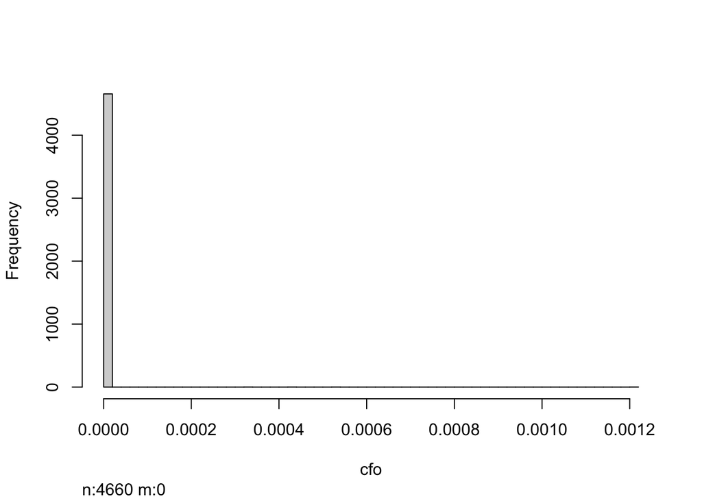

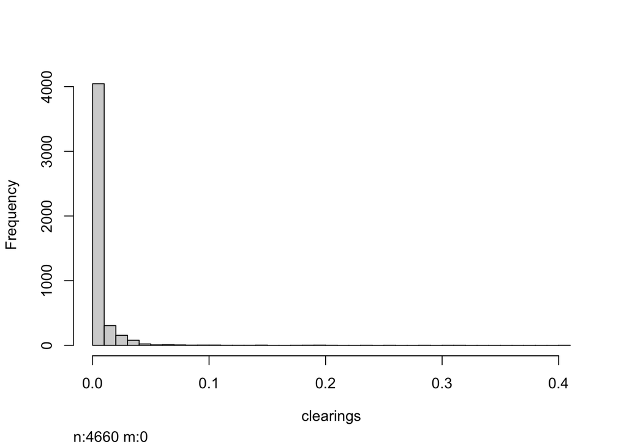

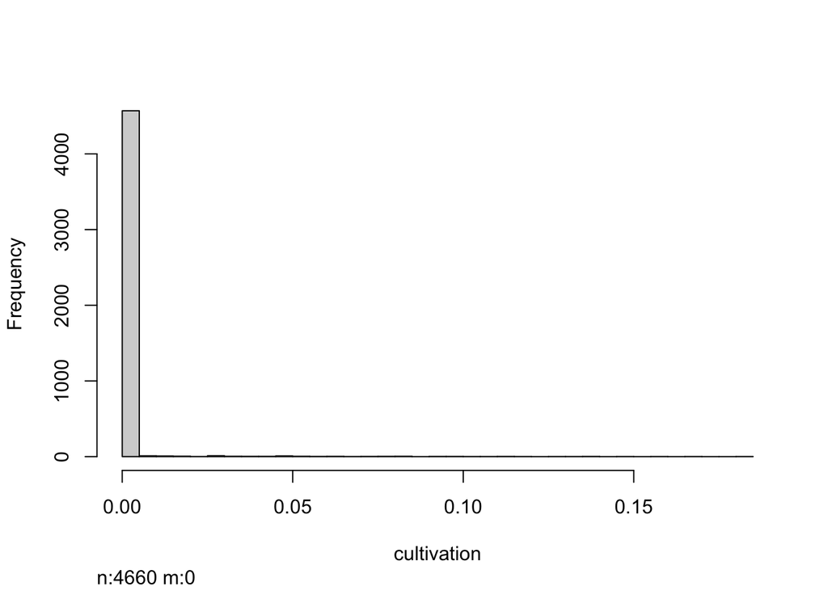

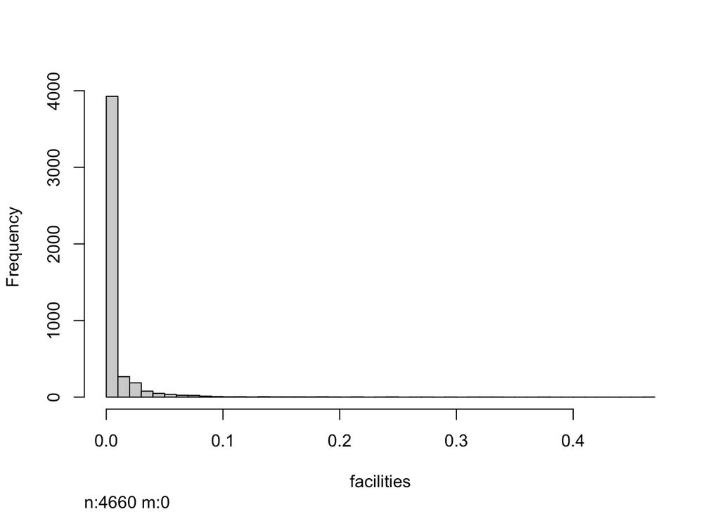

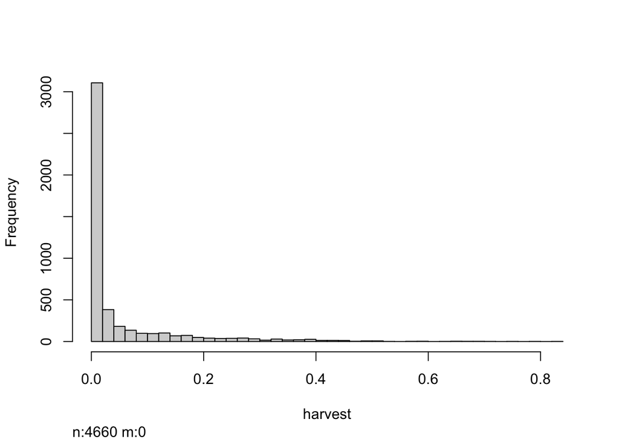

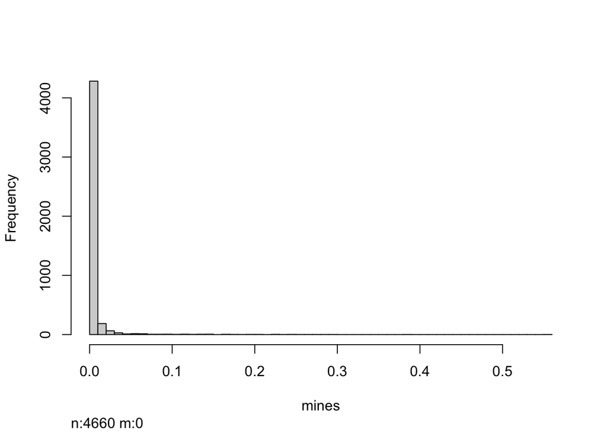

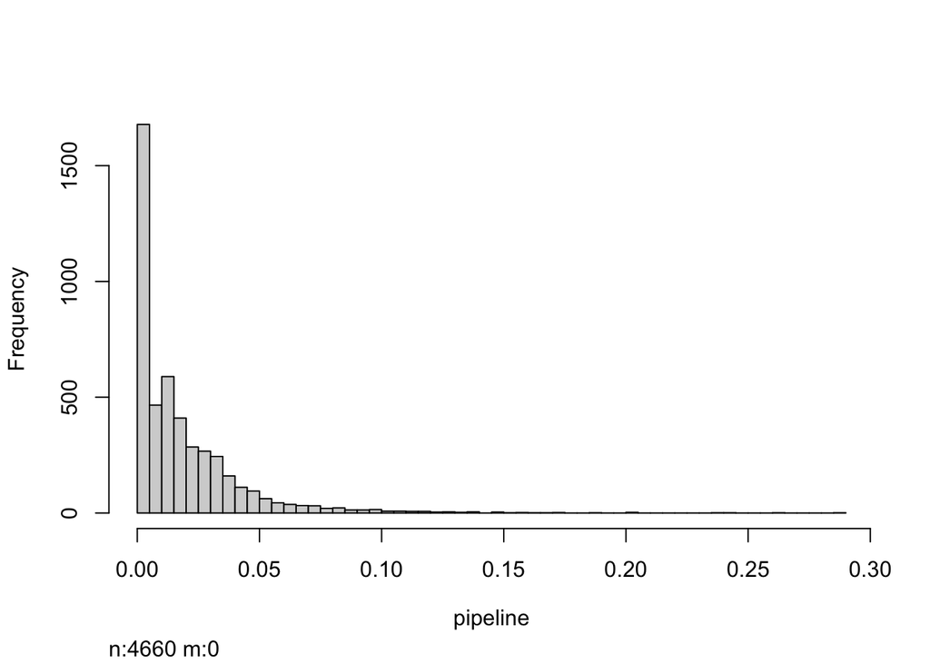

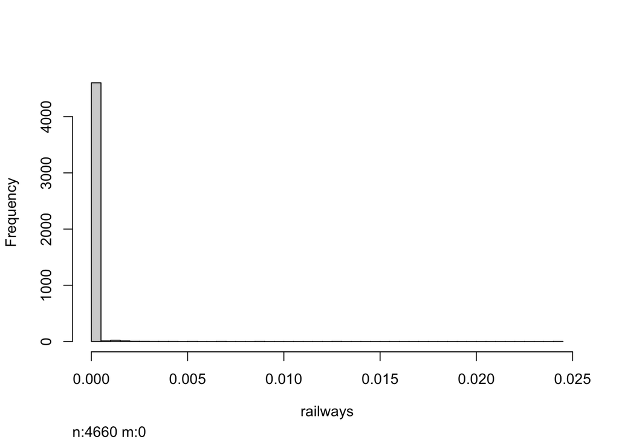

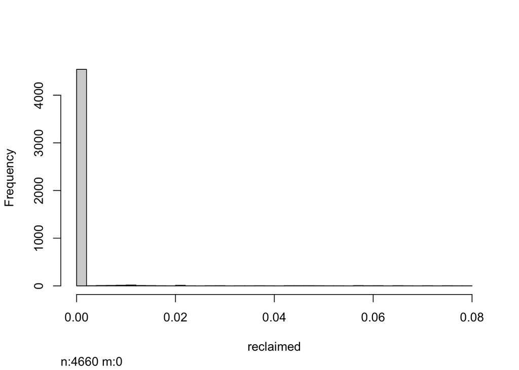

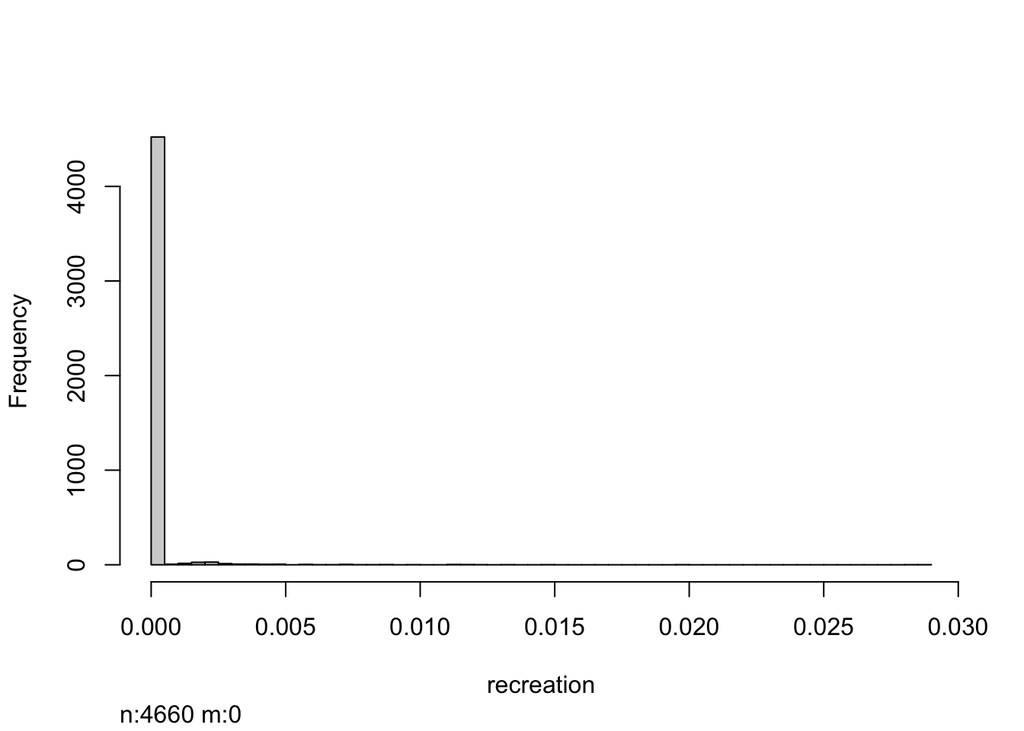

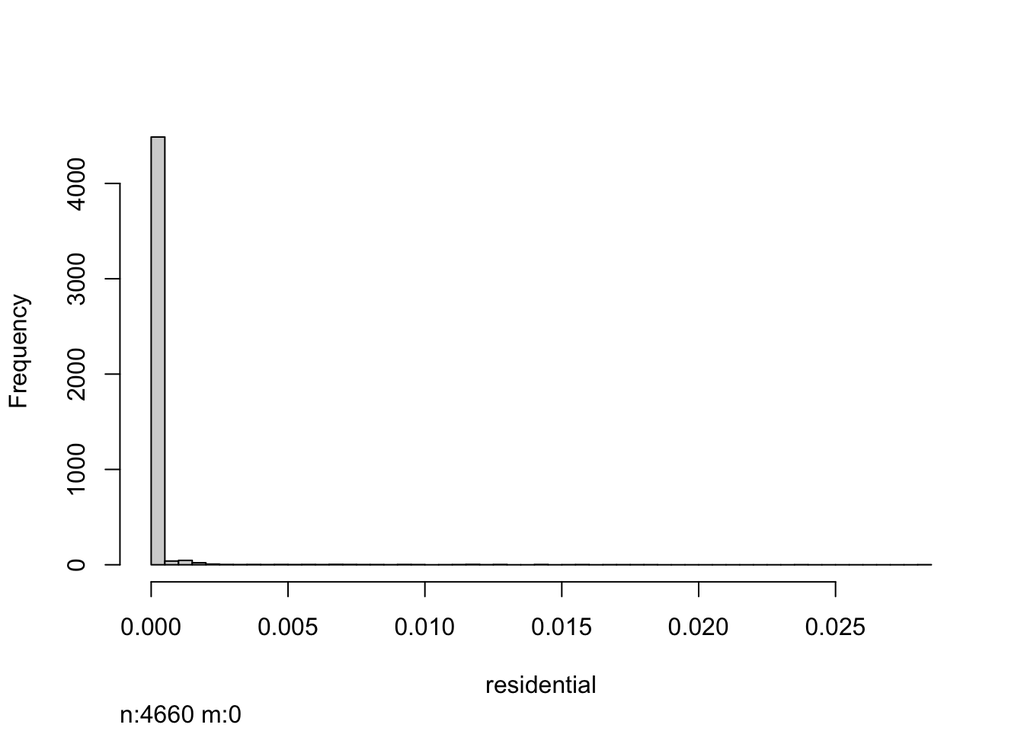

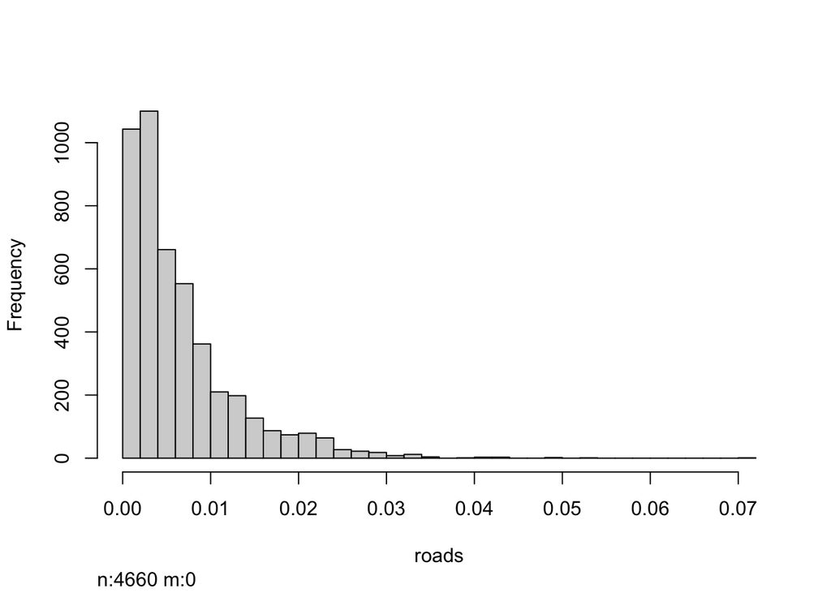

[17 more figures not shown]

```r
# use for loop to plot histograms for all covariates

for (col in 5:ncol(covariates_grouped)) {
    hist(covariates_grouped[,col])
}
```

[output not shown]

Also, there’s not a lot of data for the following features, which are similar and of interest to OSM, so in the past they’ve been grouped together and we will here as well

- Borrowpits
- Facilities
- Mines

> For this analysis we will also combine facilities and mines

## Group covariates further

So let’s modify this data and remove those features for now **this step will need to be changed each year likely**

Let’s also rename the landcover classes so they make more sense without having to look them up by number (*maybe should add this to script earlier for next year*)

```r
covariates_grouped_final <- covariates_grouped %>%

  # create column osm_industrial
  mutate(
    osm_industrial = borrowpits +
    clearings +
    facilities +
    mines,

    # remove columns we used to make this variable
    .keep = 'unused') %>%

  # remove other features we don't need
  select(!c(cfo,
            cultivation,
            reclaimed,
            recreation,
            residential,
            water,
            lc_class20,
            lc_class120,
            lc_class32,
            lc_class33,
            landfill,
            railways)) %>%

  # rename landcover classes
  rename(
    lc_grassland = lc_class110,
    lc_coniferous = lc_class210,
    lc_broadleaf = lc_class220,
    lc_mixed = lc_class230,
    lc_developed = lc_class34,
    lc_shrub = lc_class50)

# check that it worked
names(covariates_grouped)
```

```
##  [1] "array"              "site"               "buff_dist"
##  [4] "borrowpits"         "cfo"                "clearings"
##  [7] "cultivation"        "facilities"         "harvest"
## [10] "landfill"           "mines"              "pipeline"
## [13] "railways"           "reclaimed"          "recreation"
## [16] "residential"        "roads"              "seismic_lines"
## [19] "seismic_lines_3D"   "trails"             "transmission_lines"
## [22] "veg_edges"          "water"              "wells"
## [25] "lc_class110"        "lc_class120"        "lc_class20"
## [28] "lc_class210"        "lc_class220"        "lc_class230"
## [31] "lc_class32"         "lc_class33"         "lc_class34"
## [34] "lc_class50"
```

## Save grouped data

Let’s save this data now that it’s all formatted and grouped.

```r
write_csv(covariates_grouped_final,
          'data/processed/OSM_covariates_grouped_2021_2022.csv')
```

## Remove messy data

Let’s remove the data frames we no longer need.

```r
rm(covariates_fixed,
   covariates_grouped)
```

> We are done with this script for now, we have a nice clean data set with the HFI covariates grouped how we could use them in an analysis and the VEG covariates renamed so we don’t have to memorize or lookup what the numbers mean